# Mini Data-Analysis Deliverable 2

Tzu-Yi Lu, 2021 Oct 19

*To complete this milestone, you can either edit [this `.rmd` file](https://raw.githubusercontent.com/UBC-STAT/stat545.stat.ubc.ca/master/content/mini-project/mini-project-2.Rmd) directly. Fill in the sections that are commented out with `<!--- start your work here--->`. When you are done, make sure to knit to an `.md` file by changing the output in the YAML header to `github_document`, before submitting a tagged release on canvas.*

# Welcome back to your mini data analysis project!

This time, we will explore more in depth the concept of *tidy data*, and hopefully investigate further into your research questions that you defined in milestone 1.

**NOTE**: The main purpose of the mini data analysis is to integrate what you learn in class in an analysis. Although each milestone provides a framework for you to conduct your analysis, it’s possible that you might find the instructions too rigid for your data set. If this is the case, you may deviate from the instructions – just make sure you’re demonstrating a wide range of tools and techniques taught in this class.

Begin by loading your data and the tidyverse package below:

```r
library(datateachr) # <- might contain the data you picked!
library(tidyverse)
```

# Learning Objectives

By the end of this milestone, you should:

- Become familiar with manipulating and summarizing your data in tibbles using `dplyr` and `tidyr`, with a research question in mind.
- Understand what *tidy* data is, and how to create it. In milestone 3, we will explore when this might be useful.
- Generate a reproducible and clear report using R Markdown.
- Gain a greater understanding of how to use R to answer research questions about your data.

**Things to keep in mind**

- Remember to document your code, be explicit about what you are doing, and write notes in this markdown document when you feel that context is required. Create your analysis as if someone else will be reading it! **There will be 2.5 points reserved for reproducibility, readability, and repo organization.**
- Before working on each task, you should always keep in mind the specific **research question** that you’re trying to answer.

# Task 1: Process and summarize your data (15 points)

From milestone 1, you should have an idea of the basic structure of your dataset (e.g. number of rows and columns, class types, etc.). Here, we will start investigating your data more in-depth using various data manipulation functions.

### 1.1 (2.5 points)

First, write out the 4 research questions you defined in milestone 1 were. This will guide your work through milestone 2:

**(A1.1)**:

1. **Does different species have different relationships between the tree age and diameter?**
2. **Is there any obvious relationship between the root barriers the tree growth (height/diameter/curb)?**
3. **Are the trees in the same species planted in the same area? What is the spatial distribution of different tree species?**
4. **Is there any spatial trend in the tree height or diameter in different areas?**

### 1.2 (10 points)

Now, for each of your four research questions, choose one task from options 1-4 (summarizing), and one other task from 4-8 (graphing). You should have 2 tasks done for each research question (8 total). Make sure it makes sense to do them! (e.g. don’t use a numerical variables for a task that needs a categorical variable.). Comment on why each task helps (or doesn’t!) answer the corresponding research question.

Ensure that the output of each operation is printed!

**Summarizing:**

1. Compute the *range*, *mean*, and *two other summary statistics* of **one numerical variable** across the groups of **one categorical variable** from your data.
2. Compute the number of observations for at least one of your categorical variables. Do not use the function `table()`!
3. Create a categorical variable with 3 or more groups from an existing numerical variable. You can use this new variable in the other tasks! *An example: age in years into “child, teen, adult, senior”.*
4. Based on two categorical variables, calculate two summary statistics of your choosing.

**Graphing:**

5. Create a graph out of summarized variables that has at least two geom layers.
6. Create a graph of your choosing, make one of the axes logarithmic, and format the axes labels so that they are “pretty” or easier to read.
7. Make a graph where it makes sense to customize the alpha transparency.
8. Create 3 histograms out of summarized variables, with each histogram having different sized bins. Pick the “best” one and explain why it is the best.

Make sure it’s clear what research question you are doing each operation for!

**(A1.2)**

**$$Data pre-processing$$**

→ Extract datasets within the chosen areas (which are close to UBC) and name the variable as “**VanTreeUBC**”.

```r
# (0) Definition of chosen areas
# Answer: Listing all neighborhood names and pick observations in specific areas.
#         Neighborhoods located between UBC and Hwy99 are defined as chosen areas.

chosen_area <- c("ARBUTUS-RIDGE","DUNBAR-SOUTHLANDS","KITSILANO","SHAUGHNESSY","WEST POINT GREY")
VanTreeUBC <- filter(vancouver_trees, neighbourhood_name %in% chosen_area) %>%
  mutate(tree_age = as.numeric(difftime(as.Date("2021-10-09"),date_planted))/365)
```

**(Q1.2.1)**:

Does different species have different relationships between the tree age and diameter?

**(A1.2.1)**:

I choose **question-1** and **question-5** to understand the relationship between the tree age and diameter. I used the “**summarise**” function to know the overall variations of the diameter and the tree age. Because there are too many species, I only obtain the top 5% in observation amounts of species for the following analysis. Only 11 out of 219 species stay. By the answer to **question-5**, I found inconsistent relationships between the **diameter** and the **tree age**. For example, the mean tree age of **ACERIFOLIA X**(19.6 years) is smaller than **EUCHLORA X**(27.7 years), but the mean diameter of **ACERIFOLIA X**(27.3 inches) is larger than **EUCHLORA X**(13.3 inches). Therefore, *the relationships between diameter and the tree age differ from species to species*.

```r
# (1) Compute the range, mean, and two other summary statistics of diameter

# Compute the statistics of the "diameter"
Ans1.2.1_d <-VanTreeUBC %>%
  group_by(species_name) %>%
  summarise(across(diameter, .f=list("mean"=mean,"min"=min,"max"=max,"median"=min,"sd"=sd),na.rm=TRUE),n=n()) %>%
  mutate(range = diameter_max-diameter_min)
# Because there are too many species (totally 219), I only keep the first 5% (totally 11) with respect to observation amounts for the following analysis.
Ans1.2.1_d <- filter(Ans1.2.1_d, n>=quantile(Ans1.2.1_d$n,probs=0.95))
head(Ans1.2.1_d)
```

```
## # A tibble: 6 × 8
##   species_name   diameter_mean diameter_min diameter_max diameter_median
##   <chr>                  <dbl>        <dbl>        <dbl>           <dbl>
## 1 ACERIFOLIA   X         27.3             2           55               2
## 2 AMERICANA              20.9             0           55               0
## 3 CERASIFERA             11.0             0           78               0
## 4 EUCHLORA   X           13.3             1           40               1
## 5 HIPPOCASTANUM          26.0             0           64               0
## 6 KOBUS                   8.22            0           37               0
## # … with 3 more variables: diameter_sd <dbl>, n <int>, range <dbl>
```

```r
# Compute the mean tree age across different species, and keep the same species as diameter statistics (i.e. Ans1.2.1_d).
Ans1.2.1_y <-VanTreeUBC %>%
  group_by(species_name) %>%
  summarise(across(tree_age, mean,na.rm=TRUE)) %>%
  filter(species_name %in% Ans1.2.1_d$species_name)
head(Ans1.2.1_y)
```

```
## # A tibble: 6 × 2
##   species_name   tree_age
##   <chr>             <dbl>
## 1 ACERIFOLIA   X     19.6
## 2 AMERICANA          17.7
## 3 CERASIFERA         16.7
## 4 EUCHLORA   X       27.8
## 5 HIPPOCASTANUM      20.2
## 6 KOBUS              16.7
```

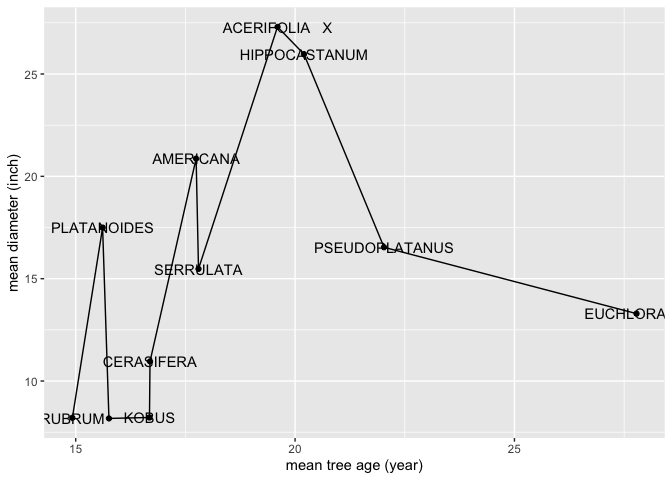

```r
# (5) Create a graph out of summarized variables that has at least two geom layers.
# I plot tree_age (x-axis) against diameter_max (y-axis).
ggplot(data=data.frame(x=Ans1.2.1_y$tree_age, y=Ans1.2.1_d$diameter_mean),aes(x=x,y=y,label=Ans1.2.1_y$species_name))+
  geom_point()+geom_line()+geom_text(check_overlap = TRUE)+
  xlab("mean tree age (year)")+ylab("mean diameter (inch)")
```

```r
# Tree age
print(format(round(Ans1.2.1_y$tree_age, 1), nsmall = 1))
```

```
##  [1] "19.6" "17.7" "16.7" "27.8" "20.2" "16.7" "15.6" "22.0" "14.9" "17.8"
## [11] "15.8"
```

```r
# Mean diameter
print(format(round(Ans1.2.1_d$diameter_mean, 1), nsmall = 1))
```

```
##  [1] "27.3" "20.9" "11.0" "13.3" "26.0" " 8.2" "17.5" "16.5" " 8.2" "15.5"
## [11] " 8.2"
```

```r
# Divide a new data.frame only with the chosen 11 species. I will use it for the following analysis.
VanTreeUBC_chosen<- VanTreeUBC %>%
  filter(species_name %in% Ans1.2.1_d$species_name)
```

**(Q1.2.2)**:

Is there any obvious relationship between the root barriers the diameter of trees?

**(A1.2.2)**:

I choose **question-2** and **question-5** to show the relationship between the root barriers and the tree diameter. According to the answer to **question-2** (Ans1.2.2), I found that most trees grew up without root barriers. Then, I further checked the diameter variations under two different conditions (with/without root barriers). Then, the trees growing up with root barriers have smaller diameters than those without root barriers according to the boxplots (the outputted plot for **question-5**) except **HIPPOCASTANUM**. Therefore, *root barriers might be a factor that influences tree growth*.

```r
# (2) Compute the number of observations for at least one of your categorical variables

# Try to count the total numbers of two categories in "root barriers" from each species.
Ans1.2.2 <- VanTreeUBC_chosen %>%
  group_by(species_name, root_barrier) %>%
  summarise(num=n()) %>%
  pivot_wider(names_from = root_barrier, values_from=num)
# Try to calculate the proportions of each category
Ans1.2.2 <- replace(Ans1.2.2,is.na(Ans1.2.2),0) %>%
  mutate(total = N+Y) %>%
  mutate(Ratio_N_perc = N/total) %>%
  mutate(Ratio_Y_perc = Y/total)

# Then, the result reveals that most observations are classified as "No root barrier".
head(Ans1.2.2)
```

```
## # A tibble: 6 × 6
## # Groups:   species_name [6]
##   species_name       N     Y total Ratio_N_perc Ratio_Y_perc
##   <chr>          <int> <int> <int>        <dbl>        <dbl>
## 1 ACERIFOLIA   X   776     3   779        0.996      0.00385
## 2 AMERICANA       1867    43  1910        0.977      0.0225
## 3 CERASIFERA      3370    50  3420        0.985      0.0146
## 4 EUCHLORA   X     722     0   722        1          0
## 5 HIPPOCASTANUM   1140     3  1143        0.997      0.00262
## 6 KOBUS            658    14   672        0.979      0.0208
```

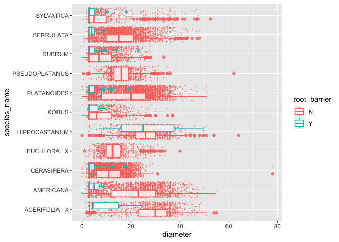

```r
# (5) Create a graph out of summarized variables that has at least two geom layers.
# Choose geom_jitter & geom_bloxplot to demonstrate the data
ggplot(VanTreeUBC_chosen,aes(y=species_name,x=diameter,colour=root_barrier))+
  geom_jitter(alpha=0.5, width=0.2,size=0.2)+
  geom_boxplot(alpha=0.8)
```

**(Q1.2.3)**:

Are the trees in the same species planted in the same area? What is the spatial distribution of different tree species?

**(A1.2.3)**:

```r
# (2) Compute the number of observations for at least one of your categorical variables.
# Use the summarise function to calculate the number
Ans1.2.3 <- VanTreeUBC_chosen %>%
  group_by(species_name, neighbourhood_name) %>%
  summarise(num=n()) %>%
  pivot_wider(names_from = neighbourhood_name, values_from=num)
```

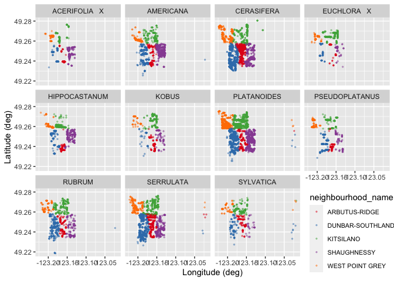

```r
# (7) Make a graph where it makes sense to customize the alpha transparency.
# Plot the distributions of trees and divide them into subplots according to species names.
# Set the transparency as 0.4, and the point size as 0.7.
ggplot(VanTreeUBC_chosen,aes(longitude,latitude,colour=neighbourhood_name))+
  geom_point(alpha=0.4,size=0.5,na.rm=TRUE)+
  xlab("Longitude (deg)")+ylab("Latitude (deg)")+
  scale_color_brewer(palette="Set1")+
  facet_wrap(~species_name)+ theme(legend.position = c(0.9, 0.1),legend.text = element_text(size=8))
```

**(Q1.2.4)**:

Is there any spatial trend in the tree diameter in different species?

**(A1.2.4)**:

I choose **question-3** and **question-7** to understand the spatial characteristics of diameter. I choose four common tree species according to the answer to **question-3** because abundant observations are useful when concluding trends. I classify trees into four levels based on the diameter measurements, including small, medium, large, and extra-large. I plot data points on the map and mark the points with different colors according to their diameter levels (the outputted plot for **question-7**). The transparency helps to distinguish the spatial distributions in the plot. I found trees with larger diameters located in the boundary of the points in the “AMERICANA” section, and those with smaller diameters located in the center of the points in the “SERRULATA” section. However, *the spatial characteristics are not obvious in all subplots*.

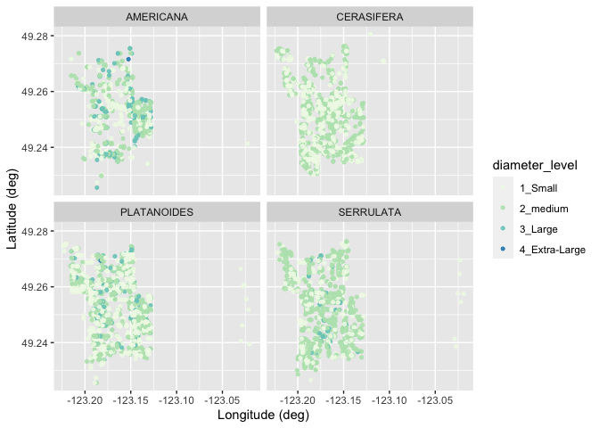

```r
# (3) Create a categorical variable with 3 or more groups from an existing numerical variable.
# Use only four common species:"AMERICANA", "CERASIFERA", "PLATANOIDES", and "SERRULATA"
# Divide diameter into 4 classes: 1_Small, 2_Median, 3_Large, and 4_ExtraLarge
Ans1.2.4 <- VanTreeUBC_chosen %>%
  filter(species_name %in% c("AMERICANA", "CERASIFERA", "PLATANOIDES", "SERRULATA")) %>%
  mutate(diameter_level = case_when(diameter<10 ~ "1_Small",
                                    diameter<30 ~ "2_medium",
                                    diameter<50 ~ "3_Large",
                                    TRUE ~ "4_Extra-Large"))

# (7) Make a graph where it makes sense to customize the alpha transparency.
# Plot the spatial distributions of the four common species with four diameter levels.
ggplot(Ans1.2.4,aes(longitude,latitude,colour=diameter_level))+
  geom_point(alpha=0.9,size=1.1,na.rm=TRUE)+
  xlab("Longitude (deg)")+ylab("Latitude (deg)")+
  scale_color_brewer(palette="GnBu")+
  facet_wrap(~species_name)
```

### 1.3 (2.5 points)

Based on the operations that you’ve completed, how much closer are you to answering your research questions? Think about what aspects of your research questions remain unclear. Can your research questions be refined, now that you’ve investigated your data a bit more? Which research questions are yielding interesting results?

**(A1.3)**:

According to the results shown above, I found that there is no specific spatial distribution in tree species. Maybe I should modify my research questions to investigate the relationship between species and tree growth variables (height/diameter/curb/tree age). That might help to identify the spatial characteristics in tree growth near UBC (The main direction addressed in milestone 1 is **" Is there any spatial difference in tree growth in the areas near UBC?"**). In my opinion, the result of Q1.2.1 is interesting. This plot implies that species might be a critical factor regarding the relationship between mean diameter and mean tree age. That is worth being further studied.

# Task 2: Tidy your data (12.5 points)

In this task, we will do several exercises to reshape our data. The goal here is to understand how to do this reshaping with the `tidyr` package.

A reminder of the definition of *tidy* data:

- Each row is an **observation**
- Each column is a **variable**
- Each cell is a **value**

*Tidy’ing* data is sometimes necessary because it can simplify computation. Other times it can be nice to organize data so that it can be easier to understand when read manually.

### 2.1 (2.5 points)

Based on the definition above, can you identify if your data is tidy or untidy? Go through all your columns, or if you have >8 variables, just pick 8, and explain whether the data is untidy or tidy.

**(A2.1)**:

The dataset I used in this mini data analysis consists of 21 variables (VanTreeUBC_chosen). I choose eight variables including “tree_id”,“root_barrier”,“height_range_id”,“diameter”,“genus_name”,“species_name”,“common_name”, and “cultivar_name”.

The “tree_id”,“root_barrier”,“height_range_id”, and “diameter” follow the three principles of tidy data mentioned above. However, the other four variables are not. The “genus_name”,“species_name”,“common_name”, and “cultivar_name” are related to names of the trees. The genus and species are taxonomic ranks used in the biological classification. Scientists use those two pieces of information to classify trees. The “common_name” and “cultivar_name” are ways how people call trees in daily life. Therefore, they should be tidied up into the same variable regarding “Name”.

```r
# Show the first 5 rows of "VanTreeUBC_chosen".
head(VanTreeUBC_chosen)
```

```
## # A tibble: 6 × 21
##   tree_id civic_number std_street   genus_name species_name cultivar_name
##     <dbl>        <dbl> <chr>        <chr>      <chr>        <chr>
## 1  155373         1900 CYPRESS ST   PRUNUS     CERASIFERA   NIGRA
## 2  155413         2485 W BROADWAY   ULMUS      AMERICANA    BRANDON
## 3  155436         3039 COURTENAY ST MAGNOLIA   KOBUS        <NA>
## 4  155446         2246 W 15TH AV    ACER       RUBRUM       KARPICK
## 5  156061         2659 W 19TH AV    FRAXINUS   AMERICANA    <NA>
## 6  156242         3638 HUDSON ST    ACER       PLATANOIDES  <NA>
## # … with 15 more variables: common_name <chr>, assigned <chr>,
## #   root_barrier <chr>, plant_area <chr>, on_street_block <dbl>,
## #   on_street <chr>, neighbourhood_name <chr>, street_side_name <chr>,
## #   height_range_id <dbl>, diameter <dbl>, curb <chr>, date_planted <date>,
## #   longitude <dbl>, latitude <dbl>, tree_age <dbl>
```

### 2.2 (5 points)

Now, if your data is tidy, untidy it! Then, tidy it back to it’s original state.

If your data is untidy, then tidy it! Then, untidy it back to it’s original state.

Be sure to explain your reasoning for this task. Show us the “before” and “after”.

**(A2.2)**:

Just like the reason mentioned in **A2.1**, the four variables (genus_name, species_name, common_name, cultivar_name) are spread from the tree names. Therefore, the way to tidy up them is to conclude the four variables into two columns. One of the two columns is used to indicate the type of the name, and the other one is used to document the strings obtained from the original four columns.

```r
# Rename the variables related the tree names. Make those variables starting with "name_".
VanTreeUBC_chosen_name <- VanTreeUBC_chosen %>%
  dplyr::rename(name_genus = "genus_name") %>%
  dplyr::rename(name_species = "species_name") %>%
  dplyr::rename(name_common = "common_name") %>%
  dplyr::rename(name_cultivar = "cultivar_name")

# Tidy up the name variables:
VanTreeUBC_chosen_name_td <- VanTreeUBC_chosen_name %>%
  pivot_longer(cols      = c(name_genus, name_species,name_common,name_cultivar),
               names_to  = c(".value", "NameType"),
               names_sep = "_")
```

### Data before tidying up

```r
head(VanTreeUBC_chosen_name)
```

```
## # A tibble: 6 × 21
##   tree_id civic_number std_street   name_genus name_species name_cultivar
##     <dbl>        <dbl> <chr>        <chr>      <chr>        <chr>
## 1  155373         1900 CYPRESS ST   PRUNUS     CERASIFERA   NIGRA
## 2  155413         2485 W BROADWAY   ULMUS      AMERICANA    BRANDON
## 3  155436         3039 COURTENAY ST MAGNOLIA   KOBUS        <NA>
## 4  155446         2246 W 15TH AV    ACER       RUBRUM       KARPICK
## 5  156061         2659 W 19TH AV    FRAXINUS   AMERICANA    <NA>
## 6  156242         3638 HUDSON ST    ACER       PLATANOIDES  <NA>
## # … with 15 more variables: name_common <chr>, assigned <chr>,
## #   root_barrier <chr>, plant_area <chr>, on_street_block <dbl>,
## #   on_street <chr>, neighbourhood_name <chr>, street_side_name <chr>,
## #   height_range_id <dbl>, diameter <dbl>, curb <chr>, date_planted <date>,
## #   longitude <dbl>, latitude <dbl>, tree_age <dbl>
```

```r
dim(VanTreeUBC_chosen_name)
```

```
## [1] 18672    21
```

### Data after tidying up

```r
head(VanTreeUBC_chosen_name_td)
```

```
## # A tibble: 6 × 19
##   tree_id civic_number std_street assigned root_barrier plant_area
##     <dbl>        <dbl> <chr>      <chr>    <chr>        <chr>
## 1  155373         1900 CYPRESS ST N        N            7
## 2  155373         1900 CYPRESS ST N        N            7
## 3  155373         1900 CYPRESS ST N        N            7
## 4  155373         1900 CYPRESS ST N        N            7
## 5  155413         2485 W BROADWAY N        N            7
## 6  155413         2485 W BROADWAY N        N            7
## # … with 13 more variables: on_street_block <dbl>, on_street <chr>,
## #   neighbourhood_name <chr>, street_side_name <chr>, height_range_id <dbl>,
## #   diameter <dbl>, curb <chr>, date_planted <date>, longitude <dbl>,
## #   latitude <dbl>, tree_age <dbl>, NameType <chr>, name <chr>
```

```r
dim(VanTreeUBC_chosen_name_td)
```

```
## [1] 74688    19
```

### 2.3 (5 points)

Now, you should be more familiar with your data, and also have made progress in answering your research questions. Based on your interest, and your analyses, pick 2 of the 4 research questions to continue your analysis in milestone 3, and explain your decision.

Try to choose a version of your data that you think will be appropriate to answer these 2 questions in milestone 3. Use between 4 and 8 functions that we’ve covered so far (i.e. by filtering, cleaning, tidy’ing, dropping irrelvant columns, etc.).

**(A2.3)**: According to the analyses in Q1.2, I decided to keep the first and the fourth research questions. 1. *Does different species have different relationships between the tree age and diameter?* 4. *Is there any spatial trend in the tree height or diameter in different areas?*

Because in the plot for Q1.2.1, I found that the mean tree diameters didn’t variate along with the mean tree age. When I marked the species name on the plot, I noticed that some species might be the potential to have a larger mean tree diameter than other species with larger mean tree age. So, it’s interesting to discuss the differences between the two variables between species.

The plot for Q1.2.3 showed an uneven distribution of trees, which reveals only the amount of information rather than the height and diameter. Only the number of observations for each species is not enough. Hence, I will discuss the spatial variation of the height/diameter measurements based on different regions rather than the species.

In conclusion, I will need the variables including “genus_name”, “species_name”, “neighbourhood_name”, “height_range_id”, “diameter”, “longitude”, “latitude”, “tree_age”. Then, I want to drop the NA data in the dataset.

In order to create a dataset for my analysis, I will need the following functions to manipulate the data:

1. filter: Extract the observations in specific areas
2. mutate: Calculate the age of trees
3. select: Select the specific variables
4. drop_na: Drop rows containing missing values

```r
# List all the neighborhoods I am interested in.
chosen_area <- c("ARBUTUS-RIDGE","DUNBAR-SOUTHLANDS","KITSILANO","SHAUGHNESSY","WEST POINT GREY")

VanTreeUBC <- vancouver_trees%>%
  # Extract the observations in specific areas
  filter(neighbourhood_name %in% chosen_area) %>%
  # Calculate the age of trees
  mutate(tree_age = as.numeric(difftime(as.Date("2021-10-09"),date_planted))/365) %>%
  # Select the specific variables
  select(c("genus_name", "species_name", "neighbourhood_name", "height_range_id", "diameter", "longitude", "latitude", "tree_age"))%>%
  # Drop rows containing missing values
  drop_na()
```

*When you are done, knit an `md` file. This is what we will mark! Make sure to open it and check that everything has knitted correctly before submitting your tagged release.*

### Attribution

Thanks to Victor Yuan for mostly putting this together.